```r
#Importing data
url <-
  'https://en.wikipedia.org/wiki/List_of_Malaysian_states_by_GDP'
Malaysia <-
  url %>%
  read_html() %>%
  html_nodes(xpath= '/html/body/div[3]/div[3]/div[4]/div/table[1]') %>%
  html_table()
Malaysia <-
  Malaysia[[1]]

colnames(Malaysia)[1] <- "State"
```

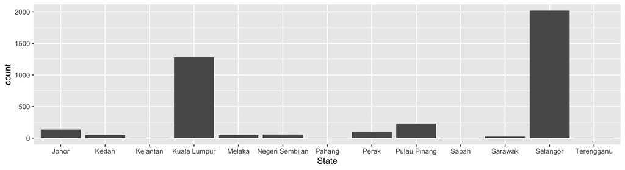

```r
PetFinder %>%
  ggplot(aes(x = State)) +
  geom_bar()
```

```r
Joined <-
  left_join(PetFinder, Malaysia, by = "State")
colnames(Joined)[19] <- "GDP"
Joined <-
  Joined %>%
  mutate(GDP = gsub(pattern = ",", replacement = "", x = GDP)) %>%
  mutate(GDP = as.numeric(GDP))
head(Joined)
```

```
##   Type      Name Age              Breed1   Breed2 Gender Color1 Color2
## 1  Dog     Puppy   2         Mixed Breed       NA   Male  Black     NA
## 2  Cat    London  24 Domestic Short Hair       NA   Male  Brown  White
## 3  Cat  Snowball  20 Domestic Short Hair       NA Female  White     NA
## 4  Cat    Malibu   5 Domestic Short Hair  Burmese Female  Black   Gray
## 5  Dog Lala Girl   6         Mixed Breed       NA Female  Black  Brown
## 6  Dog      Tipo  12         Mixed Breed Daschund Female  Black  White
##   Color3 MaturitySize FurLength Vaccinated Dewormed Sterilized  Health
## 1     NA       Medium    Medium         No       No         No Healthy
## 2     NA       Medium     Short        Yes      Yes        Yes Healthy
## 3     NA       Medium     Short        Yes      Yes        Yes Healthy
## 4  White       Medium     Short        Yes      Yes        Yes Healthy
## 5  White       Medium     Short        Yes      Yes        Yes Healthy
## 6     NA        Small     Short        Yes      Yes        Yes Healthy
##   Quantity Fee    State    GDP 2015 GDP(RM Million) 2014 GDP(RM Million)
```

[output cut: 20 more lines]

```r
mod_logit <- lm(Fee ~ GDP + Quantity,  data = Joined)
```

```r
msummary(mod_logit)
```

```
##               Estimate Std. Error t value Pr(>|t|)
## (Intercept)  1.701e+01  5.564e+00   3.057 0.002253 **
## GDP          7.210e-05  2.244e-05   3.214 0.001322 **
## Quantity    -3.337e+00  9.185e-01  -3.633 0.000284 ***
##
## Residual standard error: 89.46 on 3669 degrees of freedom
##   (276 observations deleted due to missingness)
## Multiple R-squared:  0.006467,   Adjusted R-squared:  0.005925
## F-statistic: 11.94 on 2 and 3669 DF,  p-value: 6.78e-06
```

```r
res <- 100
fake_grid <- expand.grid(
  GDP = seq(from = 280698, to = 5642, length.out = res),
  Quantity = seq(from = 20, to = 1, length.out = res))
```

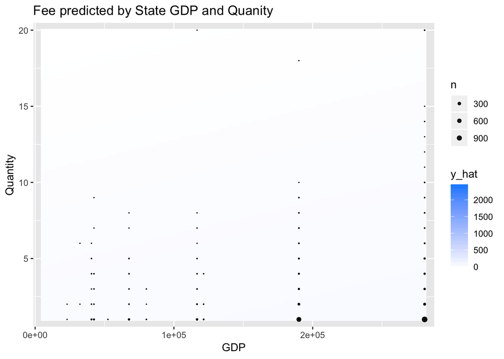

```r
pred_log <- predict(mod_logit, newdata = fake_grid, type = "response")
plot <-
  fake_grid %>%
  mutate("Logistic"= pred_log) %>%
  gather(key = "model", value = "y_hat", -GDP, -Quantity)
ggplot(data = plot, aes(x = GDP, y = Quantity)) +
  geom_tile(aes(fill = y_hat), color = NA) +
  geom_count(aes(fill = Fee), alpha = 0.9, data = Joined) +
  scale_fill_gradient(low = "white", high = "dodgerblue") +
  scale_color_manual(values = c("black", "red")) +
  scale_size(range = c(0, 2)) +
  scale_x_continuous(expand = c(0.02,0)) +
  scale_y_continuous(expand = c(0.02,0)) +
  ggtitle("Fee predicted by State GDP and Quanity")
```

With an R-squared value close to zero, we can see that there is little correlation between the fee as the response variable and quatity if that type of animal and GDP of the state the animal is from. It may be benefical for Malaysia have lower prices in lower states or transfer more expensive/disirable dogs to richer states.

```r
PetFinder <-
  PetFinder %>%
  mutate(Name = as.character(Name)) %>%
  mutate(Name = tolower(Name))
Sentiments <-
  get_sentiments("afinn")
```

```r
colnames(Sentiments)[1] <- "Name"
colnames(PetFinder)[2] <- "Name"

PetFinder_sentiment <-
  PetFinder %>%
  select(Name) %>%
  inner_join(Sentiments, PetFinder, by = 'Name') %>%
  filter(score < 0)
PetFinder_sentiment
```

```
##         Name score
## 1      angry    -3
## 2       grey    -1
## 3      rainy    -1
## 4  toothless    -2
## 5  emergency    -2
## 6        shy    -1
## 7      rainy    -1
## 8      nosey    -2
## 9      noisy    -1
## 10    sneaky    -1
## 11      envy    -1
```

There are 11 animals that have names with negative scores. Shelters may want to consider changing these names to help get these animals adpoted.

```r
PetFinderFit <-
  Joined %>%
  mutate(fit = ifelse((Vaccinated == 'Yes') & (Dewormed == 'Yes'), TRUE, FALSE)) %>%
  mutate(fit = ifelse((Sterilized == 'Yes'), TRUE, FALSE))
head(PetFinderFit)
```

```
##   Type      Name Age              Breed1   Breed2 Gender Color1 Color2
## 1  Dog     Puppy   2         Mixed Breed       NA   Male  Black     NA
## 2  Cat    London  24 Domestic Short Hair       NA   Male  Brown  White
## 3  Cat  Snowball  20 Domestic Short Hair       NA Female  White     NA
## 4  Cat    Malibu   5 Domestic Short Hair  Burmese Female  Black   Gray
## 5  Dog Lala Girl   6         Mixed Breed       NA Female  Black  Brown
## 6  Dog      Tipo  12         Mixed Breed Daschund Female  Black  White
##   Color3 MaturitySize FurLength Vaccinated Dewormed Sterilized  Health
## 1     NA       Medium    Medium         No       No         No Healthy
## 2     NA       Medium     Short        Yes      Yes        Yes Healthy
## 3     NA       Medium     Short        Yes      Yes        Yes Healthy
## 4  White       Medium     Short        Yes      Yes        Yes Healthy
## 5  White       Medium     Short        Yes      Yes        Yes Healthy
## 6     NA        Small     Short        Yes      Yes        Yes Healthy
##   Quantity Fee    State    GDP 2015 GDP(RM Million) 2014 GDP(RM Million)
```

[output cut: 20 more lines]

```r
Tally <- tally(~ fit, data = PetFinderFit)
Tally
```

```
## fit
##  TRUE FALSE
##   925  3023
```

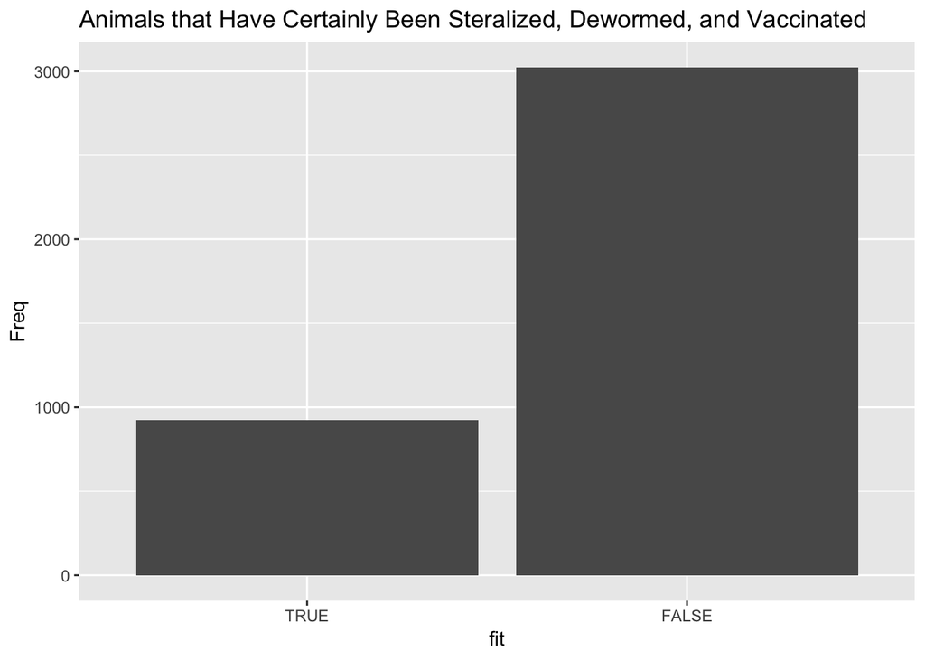

```r
ggplot(as.data.frame(Tally), aes(x = fit, y = Freq)) +
  geom_bar(stat = "identity") +
  ggtitle('Animals that Have Certainly Been Steralized, Dewormed, and Vaccinated')
```

```r
# User-Defined Function

BreedInfo <-
  function(x, y, data = PetFinder) {
    subset <-
      PetFinder %>%
      subset(PetFinder$Breed1 == x)
    subset_state <-
      PetFinder %>%
      subset(PetFinder$Breed1 == x & PetFinder$State == y)
    type <-
      subset$Type[[1]]
    n_adopted <-
      nrow(subset)
    n_adopted_state <-
      nrow(subset_state)
    avg_fee <-
      mean(subset$Fee)
    avg_fee_state <-
      mean(subset_state$Fee)
    values <-
      c(type, x, n_adopted, as.integer(avg_fee), y, n_adopted_state, as.integer(avg_fee_state))
    words <-
      c('Species', 'Breed', 'Number Adopted in Malaysia', 'Average Adoption Fee in Malaysia', 'State', 'Number Adopted in State', 'Average Adoption Fee in State')
    table <-
      do.call(rbind, Map(data.frame, Variable = words, Values = values))
    return(table)
  }

BreedInfo('Persian', 'Johor')
```

```
##                                                          Variable  Values
## Species                                                   Species     Cat
## Breed                                                       Breed Persian
## Number Adopted in Malaysia             Number Adopted in Malaysia      53
## Average Adoption Fee in Malaysia Average Adoption Fee in Malaysia     122
## State                                                       State   Johor
## Number Adopted in State                   Number Adopted in State       2
## Average Adoption Fee in State       Average Adoption Fee in State       0
```

```r
BreedInfo('Boxer', 'Selangor')
```

```
##                                                          Variable   Values
## Species                                                   Species      Dog
## Breed                                                       Breed    Boxer
## Number Adopted in Malaysia             Number Adopted in Malaysia        3
## Average Adoption Fee in Malaysia Average Adoption Fee in Malaysia      133
## State                                                       State Selangor
## Number Adopted in State                   Number Adopted in State        2
## Average Adoption Fee in State       Average Adoption Fee in State      150
```

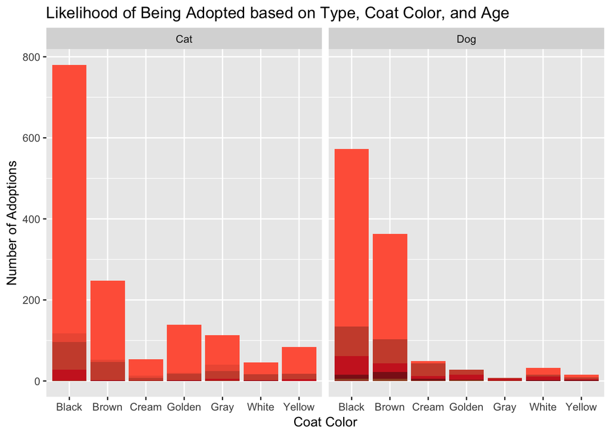

```r
# Visualization using many variables

less_half <-
  PetFinder %>%
  subset(PetFinder$Age <= 6)

half_to_one <-
  PetFinder %>%
  subset(PetFinder$Age > 7 & PetFinder$Age <= 12)

one_to_three <-
  PetFinder %>%
  subset(PetFinder$Age > 13 & PetFinder$Age <= 36)

three_to_six <-
  PetFinder %>%
  subset(PetFinder$Age > 37 & PetFinder$Age <= 72)

six_to_nine <-
  PetFinder %>%
  subset(PetFinder$Age > 73 & PetFinder$Age <= 108)

nine_to_twelve <-
  PetFinder %>%
  subset(PetFinder$Age > 109 & PetFinder$Age <= 144)

twelve_plus <-
  PetFinder %>%
  subset(PetFinder$Age > 145)

ggplot(data = PetFinder) +
  geom_bar(data = less_half, aes(x = Color1), fill = 'tomato1') +
  geom_bar(data = half_to_one, aes(x = Color1), fill = 'tomato2') +
  geom_bar(data = one_to_three, aes(x = Color1), fill = 'tomato3') +
  geom_bar(data = three_to_six, aes(x = Color1), fill = 'firebrick3') +
  geom_bar(data = six_to_nine, aes(x = Color1), fill = 'firebrick4') +
  geom_bar(data = nine_to_twelve, aes(x = Color1), fill = 'sienna') +
  geom_bar(data = twelve_plus, aes(x = Color1), fill = 'brown') +
  facet_grid(~ Type) +
  ggtitle('Likelihood of Being Adopted based on Type, Coat Color, and Age') +
  xlab('Coat Color') +
  ylab('Number of Adoptions')
```

There is an obvious preference for dark colored, younger animals when it comes to adoption in Malaysia. Because there is no way to manipulate an animals’ color or age, this could better illustrate the need to better market the availability of these animals at adoption sites.

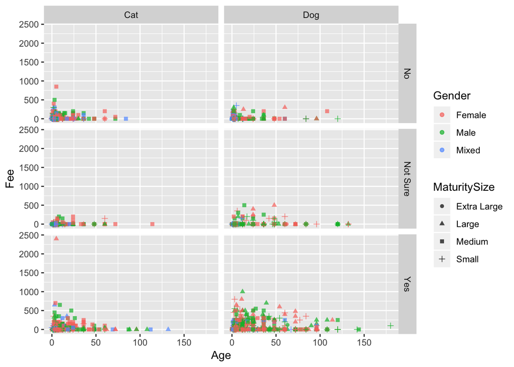

```r
# Third visualization

ggplot(data = PetFinder) +
  geom_point(aes(x = Age, y = Fee, color = Gender, shape = MaturitySize), alpha = 0.7) +
  facet_grid(Vaccinated ~ Type)
```

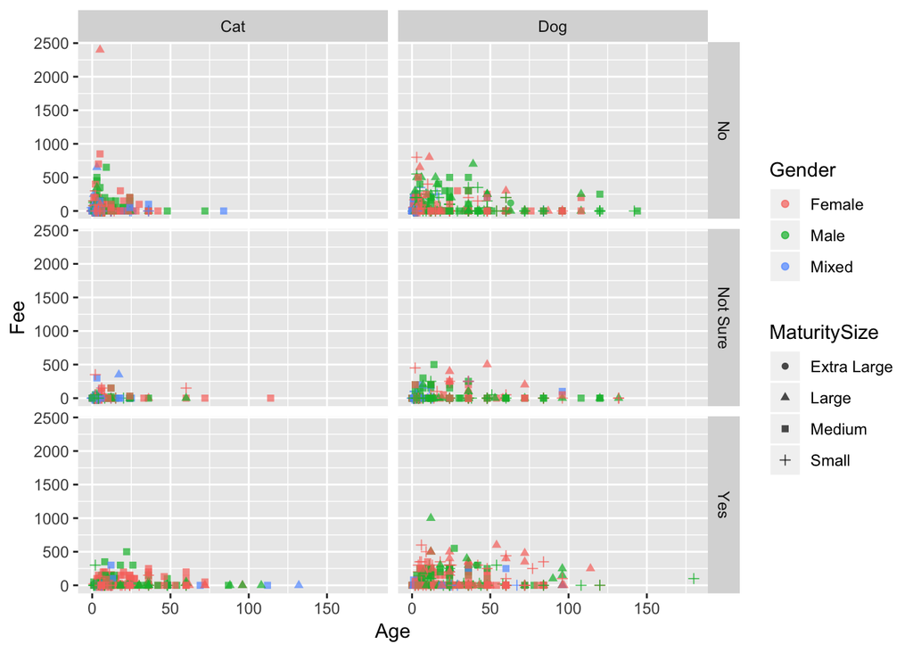

```r
ggplot(data = PetFinder) +
  geom_point(aes(x = Age, y = Fee, color = Gender, shape = MaturitySize), alpha = 0.7) +
  facet_grid(Sterilized ~ Type)
```

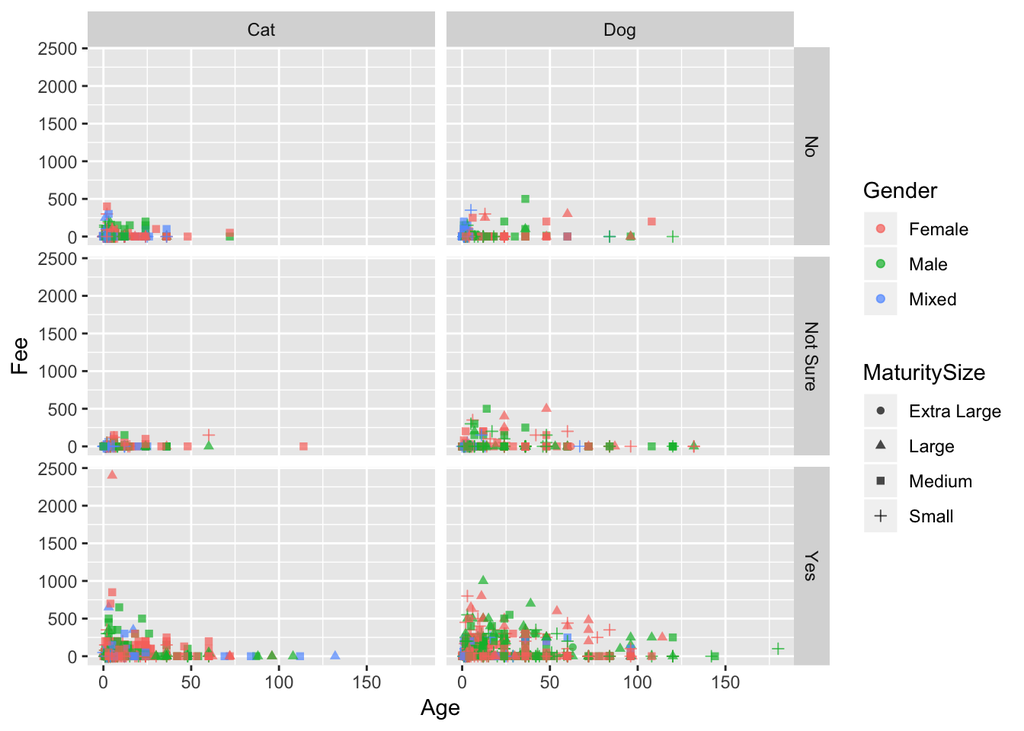

```r
ggplot(data = PetFinder) +
  geom_point(aes(x = Age, y = Fee, color = Gender, shape = MaturitySize), alpha = 0.7) +
  facet_grid(Dewormed ~ Type)
```

```r
# Simulation
avg_age <-
  mean(PetFinder)
```

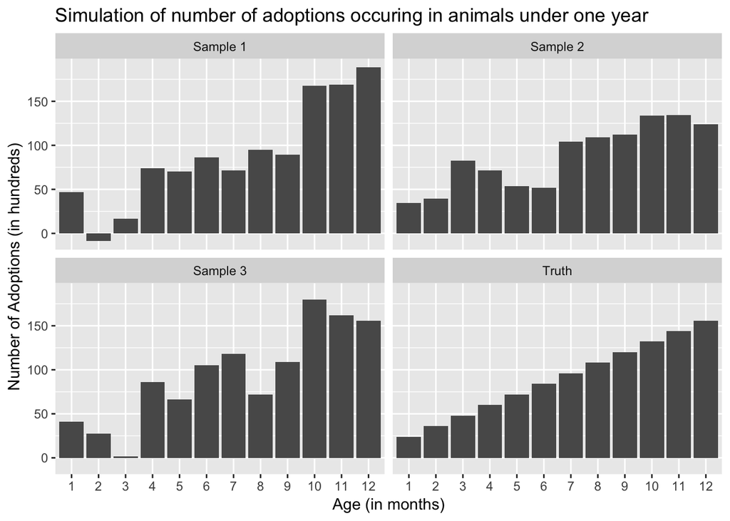

```r
set.seed(1976)

gen_samp <-
  function(true_mean, true_sd, age = 12, delta = 12, id = 1) {
    sample <-
      rep(true_mean, age) +
      rnorm(age, mean = delta * (1:age), sd = true_sd)
    return(data.frame(adoptions = sample, age_month = as.factor(1:age),
                      id = id))
  }

age_true <-
  12

age_se <-
  25

n_sims <-
  3

params <-
  data.frame(sd = c(0, rep(age_se, n_sims)), id = c('Truth', paste('Sample', 1:n_sims)))

df <-
  params %>%
  group_by(id) %>%
  do(gen_samp(true_mean = age_true, true_sd = .$sd, id = .$id))

df %>%
  ggplot(aes(x = age_month, y = adoptions)) +
  geom_bar(stat = 'identity') +
  facet_wrap(~ id) +
  xlab('Age (in months)') +
  ylab('Number of Adoptions (in hundreds)') +
  ggtitle('Simulation of number of adoptions occuring in animals under one year')
```

A simulation was performed to determine the expected adoption rates for animals under 12 months of age. Because this is the promary age group to be adopted, used in conjunction with the preceeding visualization, the expected times when these adoption rates are estimated to be low, would be the optimal time for the shelters to further advertise their less desired animals.